# Graphiques python pour l'EDO Scalaire du second ordre

## Solution analytique

```
 > fichier data/pendule.txt : 4 lignes d'entete
 < Le graphique data/pendule.pdf a ete cree.
   	Vous pouvez le visualiser avec :  okular data/pendule.pdf
```

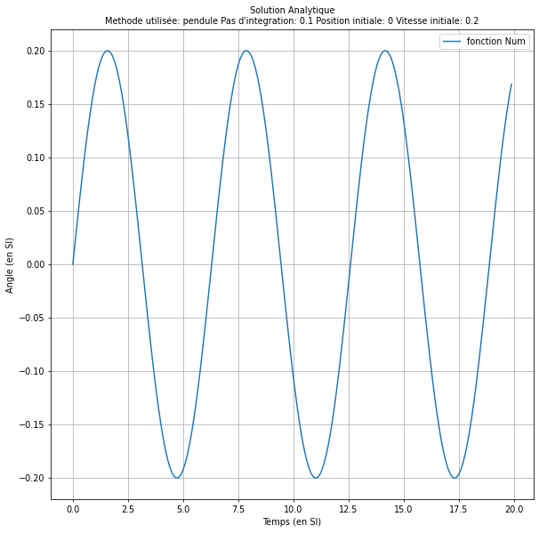

## Comparaison de la solution numerique non linéaire avec la solution analytique linéaire

- Pour un pas de 0.1

```
 > fichier data/rk4_0.1.txt : 4 lignes d'entete
 < Le graphique data/rk4_0.1.pdf a ete cree.
   	Vous pouvez le visualiser avec :  okular data/rk4_0.1.pdf
```

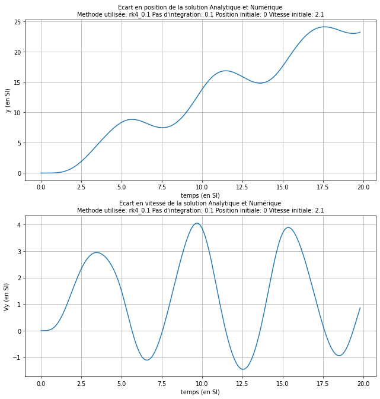

### Diagrammes de phase

- Pour un pas de 0.1:

```
 > fichier data/rk4_0.1.txt : 4 lignes d'entete
 < Le graphique data/rk4_0.1.pdf a ete cree.
   	Vous pouvez le visualiser avec :  okular data/rk4_0.1.pdf
```

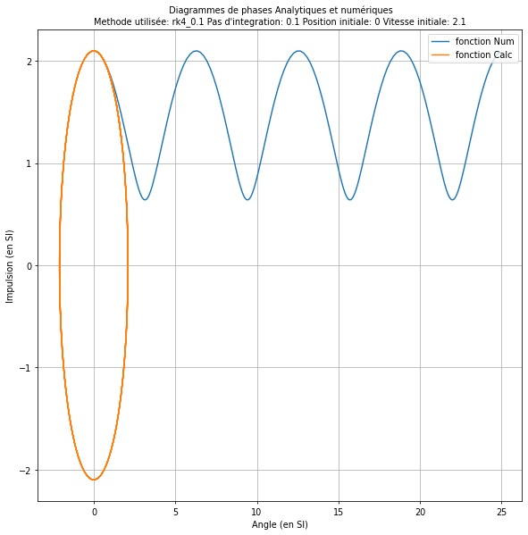

- Pour un pas de 0.01

```
 > fichier data/rk4_0.01.txt : 4 lignes d'entete
 < Le graphique data/rk4_0.01.pdf a ete cree.
   	Vous pouvez le visualiser avec :  okular data/rk4_0.01.pdf
```

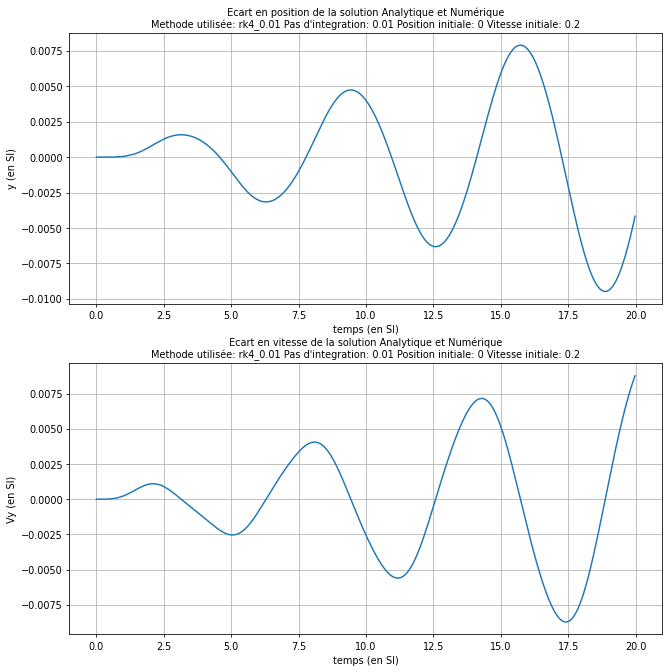

```
 > fichier data/rk4_0.01.txt : 4 lignes d'entete
 < Le graphique data/rk4_0.01.pdf a ete cree.
   	Vous pouvez le visualiser avec :  okular data/rk4_0.01.pdf
```

## Etude de l'influence du pas d'intégration sur la solution numérique en régime périodique et apériodique

Dans cette partie on souhaite analyser les differentes méthodes en vérifiant la conservation de l'énergie mécanique.

- ## Pour un pas de 0.1:

### Régime périodique:

```
 > fichier data/rk4_0.1_0.2.txt : 4 lignes d'entete
 < Le graphique data/rk4_0.1_0.2.pdf a ete cree.
   	Vous pouvez le visualiser avec :  okular data/rk4_0.1_0.2.pdf
```

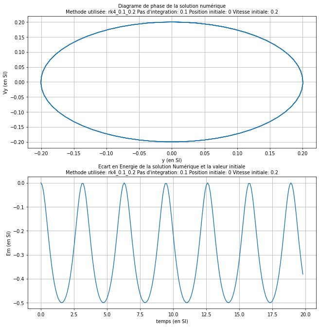

### Régime apériodique:

```
 > fichier data/rk4_0.1.txt : 4 lignes d'entete
 < Le graphique data/rk4_0.1.pdf a ete cree.
   	Vous pouvez le visualiser avec :  okular data/rk4_0.1.pdf
```

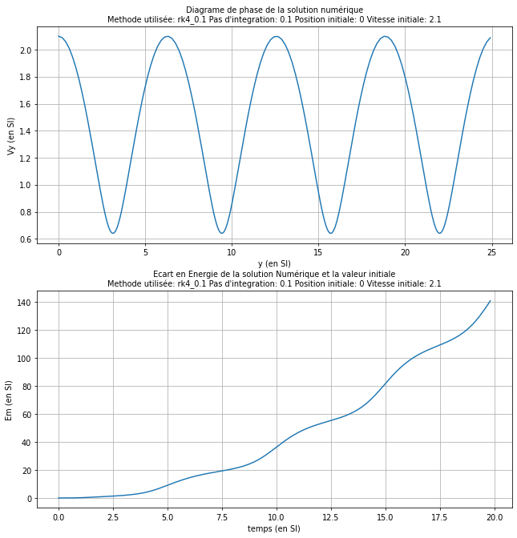

- ## Pour un pas de 0.01:

### Régime Apériodique

```
 > fichier data/rk4_0.01_2.1.txt : 4 lignes d'entete
 < Le graphique data/rk4_0.01_2.1.pdf a ete cree.
   	Vous pouvez le visualiser avec :  okular data/rk4_0.01_2.1.pdf
```

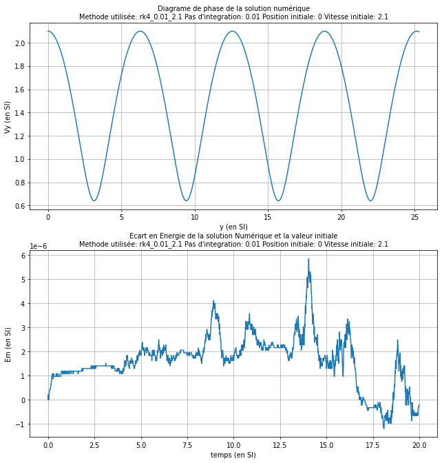

### Régime périodique

```
 > fichier data/rk4_0.01.txt : 4 lignes d'entete
 < Le graphique data/rk4_0.01.pdf a ete cree.
   	Vous pouvez le visualiser avec :  okular data/rk4_0.01.pdf
```

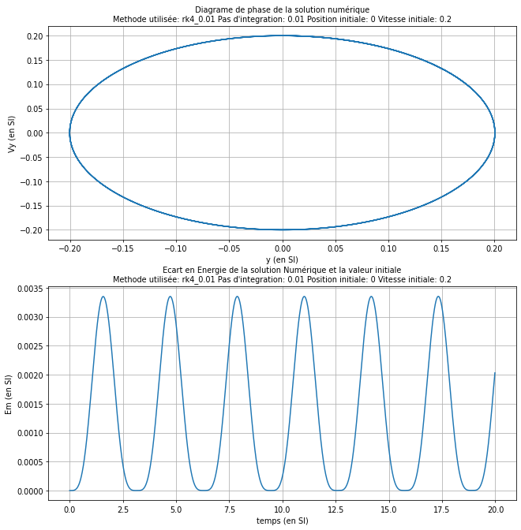

```
 > fichier data/euler_0.1_0.2.txt : 4 lignes d'entete
 < Le graphique data/euler_0.1_0.2.pdf a ete cree.
   	Vous pouvez le visualiser avec :  okular data/euler_0.1_0.2.pdf
```

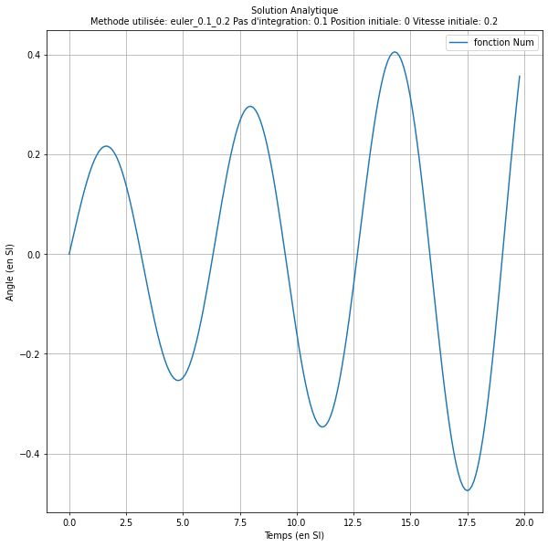

## Comparaison de la solution numerique non linéaire avec la solution analytique linéaire

- Pour un pas de 0.1

```
 > fichier data/euler_0.1_0.2.txt : 4 lignes d'entete
 < Le graphique data/euler_0.1_0.2.pdf a ete cree.
   	Vous pouvez le visualiser avec :  okular data/euler_0.1_0.2.pdf
```

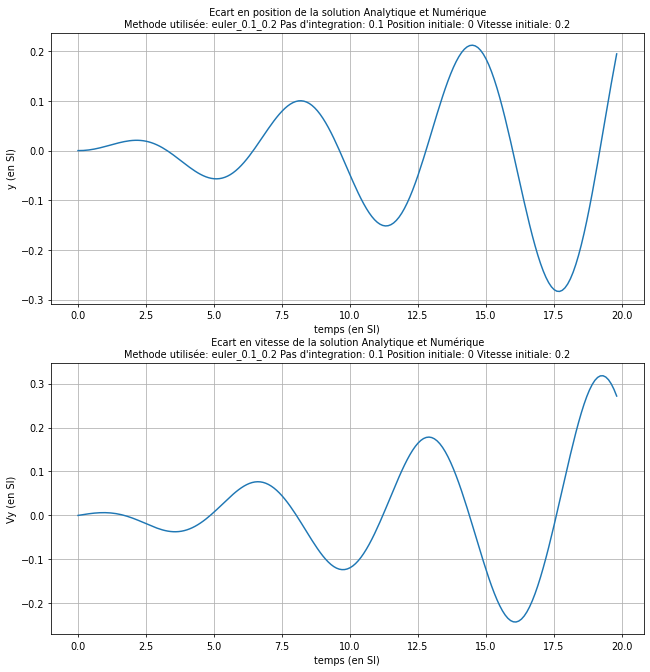

```
 > fichier data/euler_0.1_2.1.txt : 4 lignes d'entete
 < Le graphique data/euler_0.1_2.1.pdf a ete cree.
   	Vous pouvez le visualiser avec :  okular data/euler_0.1_2.1.pdf
```

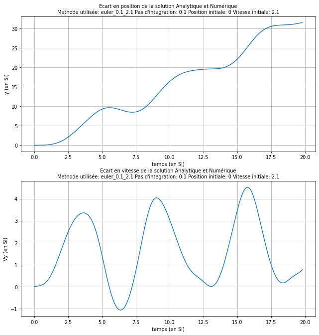

### Diagrammes de phase

- Pour un pas de 0.1:

```
 > fichier data/rk4_0.1_0.2.txt : 4 lignes d'entete
 < Le graphique data/rk4_0.1_0.2.pdf a ete cree.
   	Vous pouvez le visualiser avec :  okular data/rk4_0.1_0.2.pdf
```

[figure not shown]

```
 > fichier data/rk4_0.1_2.1.txt : 4 lignes d'entete
 < Le graphique data/rk4_0.1_2.1.pdf a ete cree.
   	Vous pouvez le visualiser avec :  okular data/rk4_0.1_2.1.pdf
```

[figure not shown]

- Pour un pas de 0.01

```
 > fichier data/euler_0.01_0.2.txt : 4 lignes d'entete
 < Le graphique data/euler_0.01_0.2.pdf a ete cree.
   	Vous pouvez le visualiser avec :  okular data/euler_0.01_0.2.pdf
```

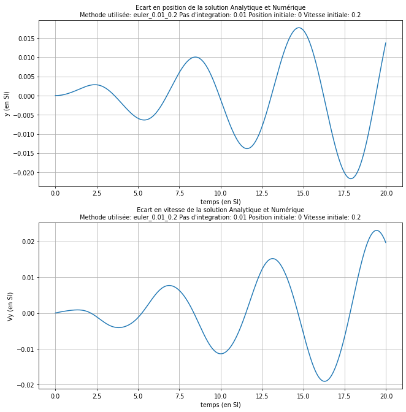

```
 > fichier data/rk4_0.01.txt : 4 lignes d'entete
 < Le graphique data/rk4_0.01.pdf a ete cree.
   	Vous pouvez le visualiser avec :  okular data/rk4_0.01.pdf
```

## Etude de l'influence du pas d'intégration sur la solution numérique en régime périodique et apériodique

Dans cette partie on souhaite analyser les differentes méthodes en vérifiant la conservation de l'énergie mécanique.

- ## Pour un pas de 0.1:

### Régime périodique:

```
 > fichier data/euler_0.1_0.2.txt : 4 lignes d'entete
 < Le graphique data/euler_0.1_0.2.pdf a ete cree.
   	Vous pouvez le visualiser avec :  okular data/euler_0.1_0.2.pdf
```

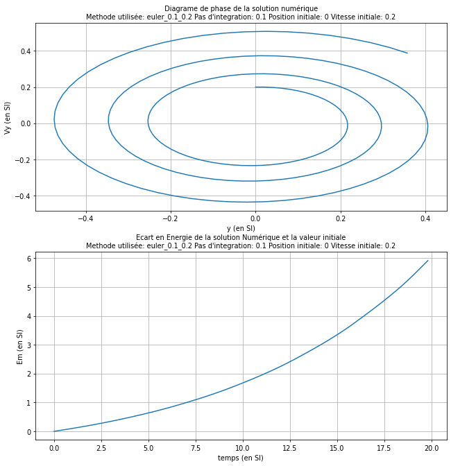

### Régime apériodique:

```
 > fichier data/euler_0.1_2.1.txt : 4 lignes d'entete
 < Le graphique data/euler_0.1_2.1.pdf a ete cree.
   	Vous pouvez le visualiser avec :  okular data/euler_0.1_2.1.pdf
```

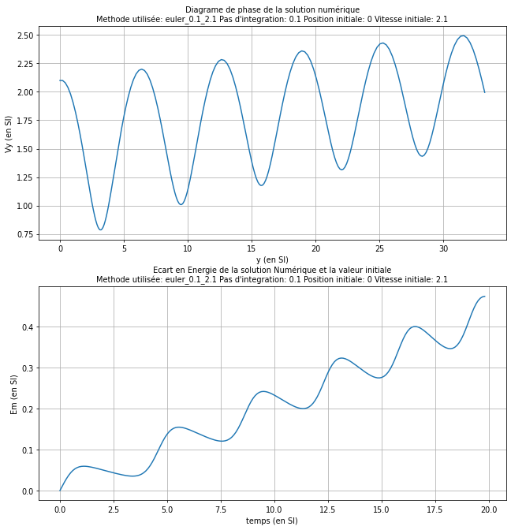

- ## Pour un pas de 0.01:

### Régime Apériodique

```
 > fichier data/euler_0.01_2.1.txt : 4 lignes d'entete
 < Le graphique data/euler_0.01_2.1.pdf a ete cree.
   	Vous pouvez le visualiser avec :  okular data/euler_0.01_2.1.pdf
```

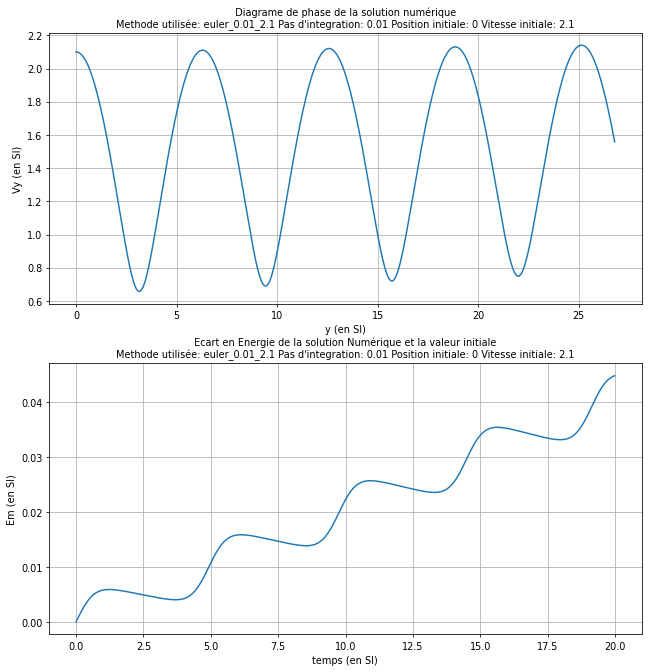

### Régime périodique

```
 > fichier data/euler_0.01_0.2.txt : 4 lignes d'entete
 < Le graphique data/euler_0.01_0.2.pdf a ete cree.
   	Vous pouvez le visualiser avec :  okular data/euler_0.01_0.2.pdf
```

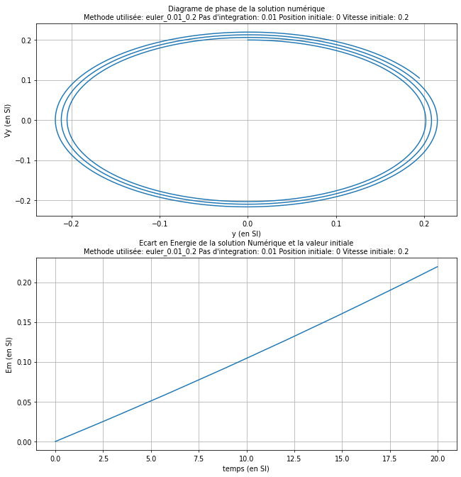

## Solution analytique

```
 > fichier data/pm_0.1_0.2.txt : 4 lignes d'entete
 < Le graphique data/pm_0.1_0.2.pdf a ete cree.
   	Vous pouvez le visualiser avec :  okular data/pm_0.1_0.2.pdf
```

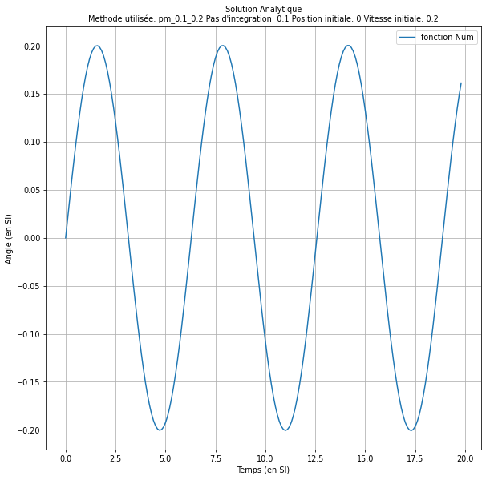

## Comparaison de la solution numerique non linéaire avec la solution analytique linéaire

- Pour un pas de 0.1

```
 > fichier data/pm_0.1_0.2.txt : 4 lignes d'entete
 < Le graphique data/pm_0.1_0.2.pdf a ete cree.
   	Vous pouvez le visualiser avec :  okular data/pm_0.1_0.2.pdf
```

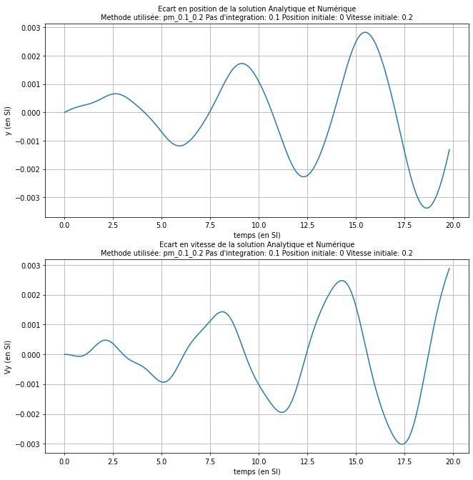

```
 > fichier data/euler_0.1_2.1.txt : 4 lignes d'entete
 < Le graphique data/euler_0.1_2.1.pdf a ete cree.
   	Vous pouvez le visualiser avec :  okular data/euler_0.1_2.1.pdf
```

[figure not shown]

### Diagrammes de phase

- Pour un pas de 0.1:

```
 > fichier data/rk4_0.1_0.2.txt : 4 lignes d'entete
 < Le graphique data/rk4_0.1_0.2.pdf a ete cree.
   	Vous pouvez le visualiser avec :  okular data/rk4_0.1_0.2.pdf
```

[figure not shown]

```
 > fichier data/rk4_0.1_2.1.txt : 4 lignes d'entete
 < Le graphique data/rk4_0.1_2.1.pdf a ete cree.
   	Vous pouvez le visualiser avec :  okular data/rk4_0.1_2.1.pdf
```

[figure not shown]

- Pour un pas de 0.01

```
 > fichier data/euler_0.01_0.2.txt : 4 lignes d'entete
 < Le graphique data/euler_0.01_0.2.pdf a ete cree.
   	Vous pouvez le visualiser avec :  okular data/euler_0.01_0.2.pdf
```

[figure not shown]

```
 > fichier data/rk4_0.01.txt : 4 lignes d'entete
 < Le graphique data/rk4_0.01.pdf a ete cree.
   	Vous pouvez le visualiser avec :  okular data/rk4_0.01.pdf
```

## Etude de l'influence du pas d'intégration sur la solution numérique en régime périodique et apériodique

Dans cette partie on souhaite analyser les differentes méthodes en vérifiant la conservation de l'énergie mécanique.

- ## Pour un pas de 0.1:

### Régime périodique:

```
 > fichier data/euler_0.1_0.2.txt : 4 lignes d'entete
 < Le graphique data/euler_0.1_0.2.pdf a ete cree.
   	Vous pouvez le visualiser avec :  okular data/euler_0.1_0.2.pdf
```

[figure not shown]

### Régime apériodique:

```
 > fichier data/euler_0.1_2.1.txt : 4 lignes d'entete
 < Le graphique data/euler_0.1_2.1.pdf a ete cree.
   	Vous pouvez le visualiser avec :  okular data/euler_0.1_2.1.pdf
```

[figure not shown]

- ## Pour un pas de 0.01:

### Régime Apériodique

```
 > fichier data/euler_0.01_2.1.txt : 4 lignes d'entete
 < Le graphique data/euler_0.01_2.1.pdf a ete cree.
   	Vous pouvez le visualiser avec :  okular data/euler_0.01_2.1.pdf
```

[figure not shown]

### Régime périodique

```
 > fichier data/euler_0.01_0.2.txt : 4 lignes d'entete
 < Le graphique data/euler_0.01_0.2.pdf a ete cree.
   	Vous pouvez le visualiser avec :  okular data/euler_0.01_0.2.pdf
```

[figure not shown]